# Week 11: Regression, part 3

PS 812 - Introduction to Statistical Methods in Political Science

Anton Strezhnev

strezhnev@wisc.edu

University of Wisconsin-Madison

November 17, 2026

## Welcome back!

$$\newcommand{\Var}{\text{Var}}
\newcommand{\Cov}{\text{Cov}}
\newcommand{\Corr}{\text{Corr}}
\newcommand{\indep}{\mathrel{\perp\mkern-10mu\perp}}$$

## Regression

## Regression is a projection

## Frisch-Waugh-Lovell

## Testing more than one coefficient

- Recall the party interaction model from last week

  $$Y_i = \beta_0 + \beta_1 \text{HS}_i + \beta_2 \text{Ind}_i + \beta_3 \text{Rep}_i + \beta_4 (\text{HS}_i \times \text{Ind}_i) + \beta_5 (\text{HS}_i \times \text{Rep}_i) + e_i$$
- Does the slope on hostile sexism **differ by party at all**?

  $$H_0: \beta_4 = 0 \text{ and } \beta_5 = 0 \qquad H_1: \beta_4 \neq 0 \text{ or } \beta_5 \neq 0$$
- Is hostile sexism related to the thermometer **in any party**?

  $$H_0: \beta_1 = \beta_4 = \beta_5 = 0$$
- Each null puts **several** restrictions on the coefficients at once

## Why not just use the individual $t$-tests?

- “Reject if **either** $t$-test rejects” is a **multiple testing** problem
  - Two tests at $\alpha = 0.05$: the chance that at least one rejects under the joint null is **above** 5%
- The two estimates are **correlated** - we can and should incorporate that into the test.
- The individual tests and the joint test can **disagree**
  - Here: $t = 0.43$ for $\hat{\beta}_4$ and $t = 1.93$ for $\hat{\beta}_5$
  - Two “almost significant” coefficients can be jointly significant or not.

## Linear hypotheses: $\mathbf{R}\boldsymbol{\beta} = \mathbf{r}$

- We can write a joint hypothesis as a set of **restrictions** on the coefficients.
- For a **linear** set of restrictions, we can express this as a matrix product:

  $$H_0: \underbrace{\mathbf{R}}_{q \times k}\ \underbrace{\boldsymbol{\beta}}_{k \times 1} = \underbrace{\mathbf{r}}_{q \times 1}$$
  - Each **row** of $\mathbf{R}$ is one restriction: a linear combination of the coefficients
  - $q$ is the **number of restrictions**
- “No difference in slopes by party”: $\beta_4 = \beta_5 = 0$

  $$\mathbf{R} = \begin{pmatrix} 0 & 0 & 0 & 0 & 1 & 0 \\ 0 & 0 & 0 & 0 & 0 & 1 \end{pmatrix} \qquad \mathbf{r} = \begin{pmatrix} 0 \\ 0 \end{pmatrix}$$

## Examples of $\mathbf{R}$ and $\mathbf{r}$

- No relationship with hostile sexism in any party, $\beta_1 = \beta_4 = \beta_5 = 0$ ($q = 3$)

  $$\mathbf{R} = \begin{pmatrix} 0 & 1 & 0 & 0 & 0 & 0 \\ 0 & 0 & 0 & 0 & 1 & 0 \\ 0 & 0 & 0 & 0 & 0 & 1 \end{pmatrix} \qquad \mathbf{r} = \begin{pmatrix} 0 \\ 0 \\ 0 \end{pmatrix}$$
- The slope among **Republicans** is zero, $\beta_1 + \beta_5 = 0$ ($q = 1$)

  $$\mathbf{R} = \begin{pmatrix} 0 & 1 & 0 & 0 & 0 & 1 \end{pmatrix} \qquad \mathbf{r} = 0$$
- Independents and Republicans have the **same** slope, $\beta_4 = \beta_5$ ($q = 1$)

  $$\mathbf{R} = \begin{pmatrix} 0 & 0 & 0 & 0 & 1 & -1 \end{pmatrix} \qquad \mathbf{r} = 0$$

## The sampling distribution of $\mathbf{R}\hat{\boldsymbol{\beta}}$

- $\mathbf{R}\hat{\boldsymbol{\beta}}$ is a **linear function** of an asymptotically normal vector, so it’s asymptotically normal too

  $$\mathbf{R}\hat{\boldsymbol{\beta}} \overset{a}{\sim} \mathcal{N}\big(\mathbf{R}\boldsymbol{\beta},\ \mathbf{R}\,\Var(\hat{\boldsymbol{\beta}})\,\mathbf{R}^\prime\big)$$
  - $\mathbf{R}\,\Var(\hat{\boldsymbol{\beta}})\,\mathbf{R}^\prime$ is the $q \times q$ variance-covariance matrix of the restricted combinations
- Plug in our estimate (e.g. the HC0 **robust** variance), $\widehat{\mathbf{V}} = \widehat{\Var}(\hat{\boldsymbol{\beta}})$
- Under $H_0$, $\mathbf{R}\hat{\boldsymbol{\beta}} - \mathbf{r}$ should be **close to zero**

## The Wald statistic

- Let’s construct a **single** statistic to build our test around.
- Take **squared distance** from the null $\mathbf{r}$, scaled by the **variance-covariance matrix**

  $$W = (\mathbf{R}\hat{\boldsymbol{\beta}} - \mathbf{r})^\prime\,\big(\mathbf{R}\widehat{\mathbf{V}}\mathbf{R}^\prime\big)^{-1}\,(\mathbf{R}\hat{\boldsymbol{\beta}} - \mathbf{r})$$
  - Without the middle matrix, this is just Euclidean distance
  - The inverse variance **rescales** each deviation by how noisy it is and **uncorrelates** them
  - The matrix version of “dividing by the variance” gives a squared **Mahalanobis** distance
- With one restriction ($q = 1$), $W$ is exactly $T^2$ - our familiar univariate test statistic squared.
- Large values of $W$ are evidence **against** $H_0$

## Why weight by the covariance?

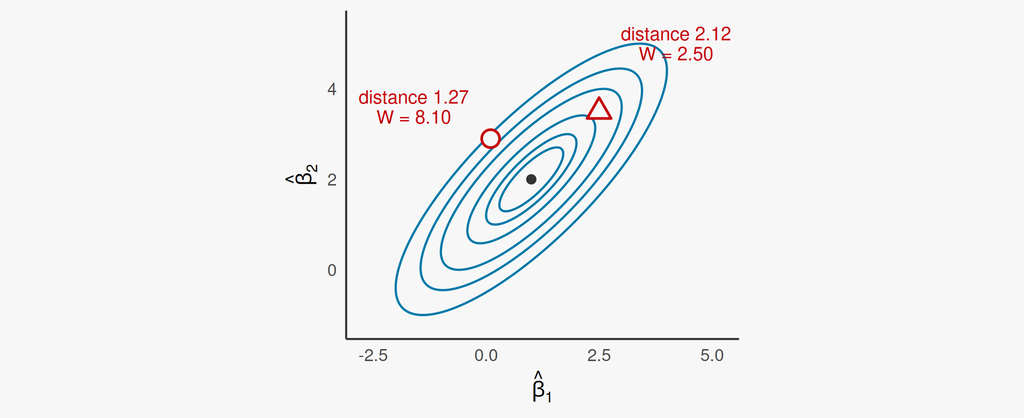

Modelled after Blackwell (2025), Figure 8.1

## The $\chi^2_q$ distribution

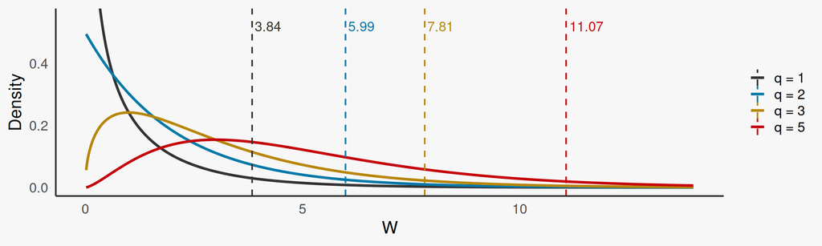

- Under $H_0$, $W \xrightarrow{d} \chi^2_q$: the sum of $q$ **independent squared** standard normals
  - Standardizing by $(\mathbf{R}\widehat{\mathbf{V}}\mathbf{R}^\prime)^{-1}$ turns the $q$ deviations into $q$ uncorrelated normals with variance $1$
- Reject at level $\alpha$ when $W > \chi^2_{q, 1 - \alpha}$. Our rejection region is **one-sided** since $W \geq 0$ (`qchisq(0.95, df = q)`)

## Example: do the party interactions matter?

```r
V_pint <- vcovHC(fit_pint, type = "HC0")       # robust variance-covariance matrix
b_pint <- coef(fit_pint)
se_pint <- sqrt(diag(V_pint))
round(cbind(estimate = b_pint, se = se_pint, t = b_pint / se_pint), 3)
```

```
                                estimate    se      t
(Intercept)                        0.950 0.489  1.942
hostile_sexism                    29.056 2.362 12.299
partyIndependent                  20.933 4.042  5.179
partyRepublican                   56.084 1.782 31.471
hostile_sexism:partyIndependent    4.118 9.502  0.433
hostile_sexism:partyRepublican     7.761 4.018  1.932
```

- Neither interaction is individually significant at 5%, but $\hat{\beta}_5$ is close
- What about **both together**?

## Wald tests by hand

```r
R <- rbind(c(0, 0, 0, 0, 1, 0),                # hostile_sexism:partyIndependent
           c(0, 0, 0, 0, 0, 1))                # hostile_sexism:partyRepublican
r <- c(0, 0)

dev <- R %*% b_pint - r                        # q x 1 deviations from the null
W <- drop(t(dev) %*% solve(R %*% V_pint %*% t(R)) %*% dev)
c(W = W, critical = qchisq(0.95, df = 2), p = pchisq(W, df = 2, lower.tail = FALSE))
```

```
        W  critical         p
3.7549954 5.9914645 0.1529724
```

- We **fail to reject** the null that the hostile sexism slope is the same in all three parties
- But we **do reject** the null that hostile sexism is entirely unrelated to Trump support ($H_0: \beta_1 = \beta_4 = \beta_5 = 0$)

```r
R3 <- rbind(c(0, 1, 0, 0, 0, 0), c(0, 0, 0, 0, 1, 0), c(0, 0, 0, 0, 0, 1))
dev3 <- R3 %*% b_pint
W3 <- drop(t(dev3) %*% solve(R3 %*% V_pint %*% t(R3)) %*% dev3)
c(W = round(W3, 1), critical = round(qchisq(0.95, df = 3), 2), p = format.pval(pchisq(W3, df = 3, lower.tail = FALSE)))
```

```
           W     critical            p
     "292.6"       "7.81" "< 2.22e-16"
```

## Wald tests in R

- `marginaleffects::hypotheses()` implements a variety of null hypothesis tests
  - Coefficient names are in `joint`
  - Select a variance estimator with `vcov`

```r
library(marginaleffects)
hypotheses(fit_pint,
           joint = c("hostile_sexism:partyIndependent", "hostile_sexism:partyRepublican"),
           vcov = "HC0", joint_test = "chisq")
```

```
Joint hypothesis test:
hostile_sexism:partyIndependent = 0
hostile_sexism:partyRepublican = 0

 ChiSq Pr(>|ChiSq|) Df
  3.75        0.153  2
```

- Careful: `joint_test` defaults to the $F$ test, and `vcov` defaults to the **classical** variance.
- `vcov` takes `"HC0"` through `"HC3"`, a clustering formula for clustered SEs `~ state`, or a matrix computed elsewhere (like `sandwich`).

## Wald tests and $F$-tests

- What regression software reports by default is an **$F$-statistic**

  $$F = \frac{W}{q}$$
  - Almost always using **classical** (homoskedastic) standard errors and compared against an $F_{q,\, n-k}$ distribution
  - This test is exact **only** under homoskedastic, normal errors
- In large samples $q \cdot F_{q, n-k}$ and $\chi^2_q$ are equivalent.
  - The $F$ is a slightly more **conservative** small-sample correction
- The $F$-test at the bottom of `summary(lm())` tests that **every** coefficient except the intercept is zero
  - Rarely an interesting hypothesis!

```r
fit_add <- lm(ft_trump ~ hostile_sexism + party, data = anes)
anova(fit_add, fit_pint)                       # classical F-test of the two interactions
```

```
Analysis of Variance Table

Model 1: ft_trump ~ hostile_sexism + party
Model 2: ft_trump ~ hostile_sexism * party
  Res.Df     RSS Df Sum of Sq      F Pr(>F)
1   4570 2314789
2   4568 2312595  2    2193.9 2.1668 0.1147
```

## One restriction: $W = T^2$

- With a single restriction, $\mathbf{R}$ is a $1 \times k$ row and $r$ is a number, so $W$ is a **scalar**

  $$W = \frac{(\mathbf{R}\hat{\boldsymbol{\beta}} - r)^2}{\mathbf{R}\widehat{\mathbf{V}}\mathbf{R}^\prime} = \left(\frac{\mathbf{R}\hat{\boldsymbol{\beta}} - r}{\widehat{SE}(\mathbf{R}\hat{\boldsymbol{\beta}})}\right)^2 = T^2$$
- And $\chi^2_1$ is the distribution of a **squared** standard normal
  - $\chi^2_{1, 0.95} = 3.84 = 1.96^2$
  - The Wald test with $q = 1$ **is** the two-sided $t$-test
- So the $t$-test works for **any** linear combination, with standard error

  $$\widehat{SE}(\mathbf{R}\hat{\boldsymbol{\beta}}) = \sqrt{\mathbf{R}\widehat{\mathbf{V}}\mathbf{R}^\prime} = \sqrt{\sum_j R_j^2 \widehat{\Var}(\hat{\beta}_j) + 2\sum_{j < l} R_j R_l \widehat{\Cov}(\hat{\beta}_j, \hat{\beta}_l)}$$
  - E.g. the **sum** of two coefficients. Don’t forget the **covariance**!

  $$\widehat{SE}(\hat{\beta}_1 + \hat{\beta}_5) = \sqrt{\widehat{\Var}(\hat{\beta}_1) + \widehat{\Var}(\hat{\beta}_5) + 2\,\widehat{\Cov}(\hat{\beta}_1, \hat{\beta}_5)}$$

## Testing a linear combination

- The slope among **Republicans** is $\beta_1 + \beta_5$, and the difference between Independents and Republicans is $\beta_4 - \beta_5$

```r
lin_comb <- function(R, b, V) {
  est <- sum(R * b)                           # R b-hat
  se <- sqrt(drop(R %*% V %*% R))             # R V R', covariances included
  c(estimate = est, se = se, t = est / se, W = (est / se)^2,
    lower = est - qnorm(0.975) * se, upper = est + qnorm(0.975) * se)
}
round(rbind(
  republican_slope = lin_comb(c(0, 1, 0, 0, 0, 1), b_pint, V_pint),
  ind_minus_rep    = lin_comb(c(0, 0, 0, 0, 1, -1), b_pint, V_pint)
), 3)
```

```
                 estimate    se      t       W   lower  upper
republican_slope   36.818 3.250 11.329 128.348  30.448 43.187
ind_minus_rep      -3.643 9.761 -0.373   0.139 -22.774 15.488
```

```r
hypotheses(fit_pint, hypothesis = "hostile_sexism + `hostile_sexism:partyRepublican` = 0", vcov = "HC0")
```

```
                                        Hypothesis Estimate Std. Error    z Pr(>|z|)    S 2.5 % 97.5 %
 hostile_sexism+`hostile_sexism:partyRepublican`=0     36.8       3.25 11.3   <0.001 96.4  30.4   43.2
```

- The covariance term matters: $\widehat{\Cov}(\hat{\beta}_1, \hat{\beta}_5) = -5.58$ is large and negative

## The geometry of least squares

- The **column space** of $\mathbf{X}$ is every linear combination of its columns

  $$\mathcal{C}(\mathbf{X}) = \{\mathbf{X}\mathbf{b} : \mathbf{b} \in \mathbb{R}^k\}$$
  - Every possible vector of **linear predictions** of $\mathbf{Y}$ from $\mathbf{X}$
- $\hat{\mathbf{Y}} = \mathbf{X}\hat{\boldsymbol{\beta}}$ is the point in $\mathcal{C}(\mathbf{X})$ **closest** to $\mathbf{Y}$: its **projection**
- The shortest path from a point to a plane meets it at a **right angle**, so the residual is **orthogonal** to every column of $\mathbf{X}$

  $$\mathbf{X}^\prime\hat{\mathbf{e}} = \mathbf{X}^\prime(\mathbf{Y} - \mathbf{X}\hat{\boldsymbol{\beta}}) = \mathbf{0}$$
- With an intercept: $\sum_i \hat{e}_i = 0$ and $\sum_i \hat{e}_i X_{ij} = 0$ for every covariate.

## The hat matrix

- Solving the normal equations and multiplying through by $\mathbf{X}$

  $$\hat{\mathbf{Y}} = \mathbf{X}\hat{\boldsymbol{\beta}} = \underbrace{\mathbf{X}(\mathbf{X}^\prime\mathbf{X})^{-1}\mathbf{X}^\prime}_{\mathbf{P}}\,\mathbf{Y}$$
- $\mathbf{P}$ is the $n \times n$ **projection matrix** onto the **column space** of $\mathbf{X}$
  - Also called the **hat matrix**: it “puts the hat on” $\mathbf{Y}$
- Multiplying **any** vector by $\mathbf{P}$ gives its best linear prediction from $\mathbf{X}$
  - $\mathbf{P}\mathbf{Z}$ = the fitted values from regressing $\mathbf{Z}$ on $\mathbf{X}$

## Properties of the hat matrix

- **Leaves $\mathcal{C}(\mathbf{X})$ alone**: anything already in the column space is its own projection

  $$\mathbf{P}\mathbf{X} = \mathbf{X}(\mathbf{X}^\prime\mathbf{X})^{-1}\mathbf{X}^\prime\mathbf{X} = \mathbf{X}$$
- **Idempotent**: projecting twice is the same as projecting once, $\mathbf{P}\mathbf{P} = \mathbf{P}$
  - Regressing the fitted values on $\mathbf{X}$ returns the same fitted values
- **Symmetric**: $\mathbf{P}^\prime = \mathbf{P}$
- **Trace** (sum of the diagonals) equals the number of parameters $k$

  $$\text{tr}(\mathbf{P}) = \text{tr}\big(\mathbf{X}(\mathbf{X}^\prime\mathbf{X})^{-1}\mathbf{X}^\prime\big) = \text{tr}\big((\mathbf{X}^\prime\mathbf{X})^{-1}\mathbf{X}^\prime\mathbf{X}\big) = \text{tr}(\mathbf{I}_k) = k$$

## The residual maker

- The complement of $\mathbf{P}$ is the **annihilator** or **residual maker**

  $$\mathbf{M} = \mathbf{I}_n - \mathbf{P} \qquad \mathbf{M}\mathbf{Y} = \mathbf{Y} - \hat{\mathbf{Y}} = \hat{\mathbf{e}}$$
- It projects onto everything **orthogonal** to $\mathcal{C}(\mathbf{X})$
  - **Annihilates** $\mathbf{X}$: $\mathbf{M}\mathbf{X} = \mathbf{X} - \mathbf{P}\mathbf{X} = \mathbf{0}$
  - Also symmetric and idempotent. $\text{tr}(\mathbf{M}) = n - k$
  - $\mathbf{P}\mathbf{M} = \mathbf{0}$: the fitted values and the residuals are **orthogonal**
- Regression splits the outcome into two **perpendicular** pieces

  $$\mathbf{Y} = \mathbf{P}\mathbf{Y} + \mathbf{M}\mathbf{Y} = \hat{\mathbf{Y}} + \hat{\mathbf{e}}$$
  - The part that’s **explained** by $\mathbf{X}$ and the part that isn’t explained by $\mathbf{X}$

## How well does the regression fit?

## $R^2$

- **Without** covariates, our best predictor is the **mean**. What’s left over is the **total** sum of squares

$$TSS = \sum_{i=1}^n (Y_i - \bar{Y})^2$$

- **With** covariates, our best linear predictor is the OLS fit. What’s left over is the **sum of squared residuals**

  $$SSR = \sum_{i=1}^n (Y_i - \mathbf{X}_i^\prime\hat{\boldsymbol{\beta}})^2$$
- The **coefficient of determination** ($R^2$) is the share of the prediction error removed by using $\mathbf{X}_i$ over just the intercept.

  $$R^2 = \frac{TSS - SSR}{TSS} = 1 - \frac{SSR}{TSS}$$
- $0 \leq R^2 \leq 1$. Adding covariates is never **worse** than the mean (in-sample). And it can never explain more than what’s there to explain!

## $R^2$

```r
fit_full <- lm(ft_trump ~ hostile_sexism + racial_resentment + party, data = anes)
fits <- list(`HS` = fit_hs, `HS + RR` = fit_rr, `HS + RR + party` = fit_full, `HS x party` = fit_pint)
round(sapply(fits, \(f) c(R2 = summary(f)$r.squared, adj_R2 = summary(f)$adj.r.squared)), 3)
```

```
          HS HS + RR HS + RR + party HS x party
R2     0.252   0.415           0.684      0.671
adj_R2 0.252   0.415           0.684      0.671
```

- Hostile sexism **alone** removes about 25% of the squared prediction error. Adding racial resentment and party brings it to 68%.
- But $R^2$ can **never** go down when we add a covariate, even pure noise

```r
set.seed(812)
noise <- matrix(rnorm(nrow(anes) * 100), ncol = 100)    # 100 columns of random numbers
fit_noise <- lm(anes$ft_trump ~ anes$hostile_sexism + noise)
round(c(R2 = summary(fit_hs)$r.squared, R2_with_noise = summary(fit_noise)$r.squared), 4)
```

```
           R2 R2_with_noise
       0.2522        0.2656
```

## What $R^2$ does and doesn’t tell us

- OLS **minimizes** SSR in the sample, so adding predictors can only improve the fit **in-sample**
  - **Adjusted** $R^2 = 1 - \frac{SSR/(n-k)}{TSS/(n-1)}$ penalizes the $R^2$ for each additional parameter, but it’s an ad-hoc correction.
  - Rather, we evaluate prediction quality by looking **out of sample** (e.g. **leave-one-out** cross-validation)
- A **low** $R^2$ does **not** mean the coefficients are wrong or uninteresting
  - Lots of $Y$ varies for reasons unrelated to $\mathbf{X}$. That’s fine if we care about $\beta_j$
- A **high** $R^2$ does **not** mean the CEF is linear, the model is “right,” or the coefficients are causal

## “Better regressions most of the time”

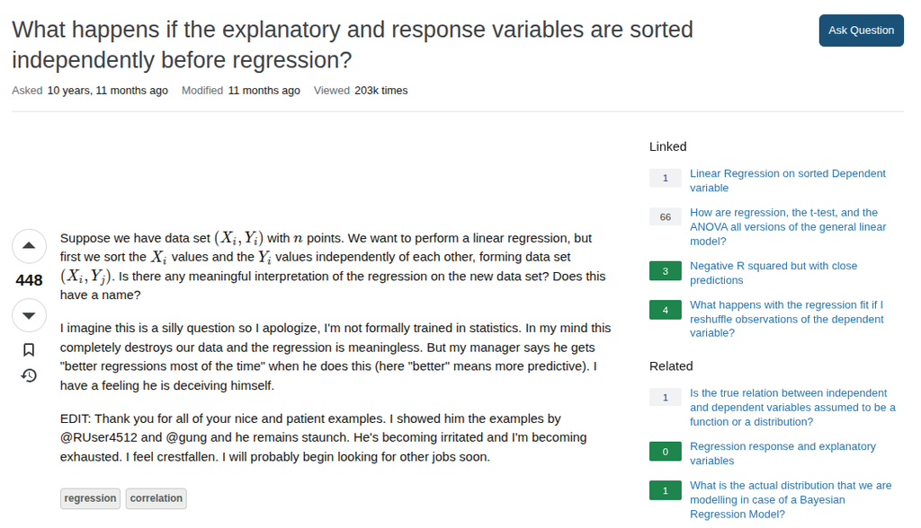

## “Better regressions most of the time”

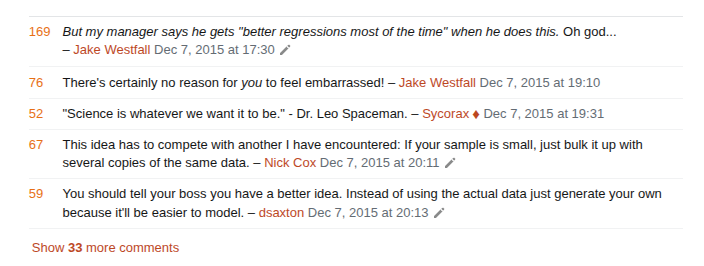

## Outliers, leverage, and influence

- OLS minimizes **squared** residuals, so it works hardest to shrink the **biggest** ones
- With an intercept, the fit always passes through the **means**: $\bar{Y} = \bar{\mathbf{X}}^\prime\hat{\boldsymbol{\beta}}$
  - Points near $\bar{\mathbf{X}}$ can shift the line **up or down** but can’t **tilt** it much
  - Points far from $\bar{\mathbf{X}}$ can move the “lever” a lot.
- **Influence** consists of two elements:
  1. **Leverage**: $\mathbf{X}_i$ is extreme - far from $\bar{\mathbf{X}}$
  2. An **outlier**: $Y_i$ far from where the **other** observations would predict it to be

## Leverage

- The **leverage** of observation $i$ is the $i$th **diagonal** of the hat matrix

  $$h_{ii} = \mathbf{X}_i^\prime(\mathbf{X}^\prime\mathbf{X})^{-1}\mathbf{X}_i = [\mathbf{P}]_{ii}$$
- Recall $\hat{\mathbf{Y}} = \mathbf{P}\mathbf{Y}$, so every fitted value is a weighted sum of **all** the outcomes

  $$\hat{Y}_i = \sum_{j=1}^n h_{ij}Y_j = h_{ii}Y_i + \sum_{j \neq i} h_{ij} Y_j$$
  - $h_{ij}$: how much $Y_j$ moves the fitted value for $i$
  - $h_{ii}$: how much $Y_i$ moves **its own** fitted value
- In a **bivariate** regression

  $$h_{ii} = \frac{1}{n} + \frac{(X_i - \bar{X})^2}{\sum_{j=1}^n (X_j - \bar{X})^2}$$

## Properties of leverage

- $0 \leq h_{ii} \leq 1$, and $h_{ii} \geq 1/n$
- Leverages **sum** to the number of regressors: $\sum_{i} h_{ii} = \text{tr}(\mathbf{P}) = k$
  - So the **average** leverage is $k / n$
- $h_{ii} = 1$: the fit passes **exactly** through $Y_i$
  - E.g. the only observation in a category that gets its own dummy

## Where is leverage high?

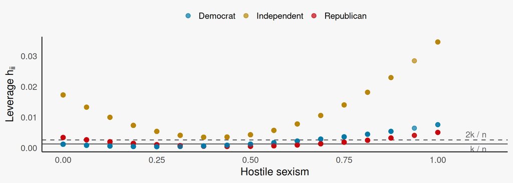

## Residuals at high-leverage points

- A high-leverage point pulls the fit **toward itself**, so its own residual comes out **small**
- Recall $\hat{\mathbf{e}} = \mathbf{M}\mathbf{e}$. If the true errors were homoskedastic, $\Var(e_i \mid \mathbf{X}) = \sigma^2$, then

  $$\Var(\hat{\mathbf{e}} \mid \mathbf{X}) = \mathbf{M}\sigma^2\mathbf{M}^\prime = \sigma^2\mathbf{M} \qquad \Var(\hat{e}_i \mid \mathbf{X}) = \sigma^2(1 - h_{ii})$$
  - The residuals are **less** variable than the errors - the variance is **smaller** for high-leverage points.
  - Where $h_{ii} \to 1$, the residual is forced to zero!
- So the residual $\hat{e}_i$ **understates** how badly the fit predicts $Y_i$
  - Observation $i$ helped choose its own fitted value. It’s an “in-sample” prediction

## Leaving one observation out

- Often we want to know how much the regression will change if we **leave out** a particular observation
  - Let $\hat{\boldsymbol{\beta}}_{(-i)}$ be the estimated coefficients, leaving out observation $i$
  - The **leave-one-out (LOO)** prediction error is $\tilde{e}_i = Y_i - \mathbf{X}_i^\prime\hat{\boldsymbol{\beta}}_{(-i)}$
- We don’t actually have to run $n$ separate regressions. There’s a closed form expression in terms of the **full** fit
  $$\tilde{e}_i = \frac{\hat{e}_i}{1 - h_{ii}} \qquad \hat{\boldsymbol{\beta}} - \hat{\boldsymbol{\beta}}_{(-i)} = (\mathbf{X}^\prime\mathbf{X})^{-1}\mathbf{X}_i\tilde{e}_i$$
  - The LOO error **inflates** the residual by $1 / (1 - h_{ii})$ - most of the impact is at *high leverage*
  - The coefficients move in proportion to the LOO error.
- $\sum_i \tilde{e}_i^2$ is an **out-of-sample** measure of fit.

## Leverage and influence in action

## Measuring influence: DFBETA and Cook’s distance

- **DFBETA**: how much each coefficient moves when we drop observation $i$

  $$\text{DFBETA}_i = \hat{\boldsymbol{\beta}} - \hat{\boldsymbol{\beta}}_{(-i)} = (\mathbf{X}^\prime\mathbf{X})^{-1}\mathbf{X}_i\tilde{e}_i$$
  - One value per observation **and** coefficient. Divide by the coefficient’s SE for **DFBETAS**
- How much does dropping $i$ move **its own** fitted value?

  $$\hat{Y}_i - \mathbf{X}_i^\prime\hat{\boldsymbol{\beta}}_{(-i)} = \mathbf{X}_i^\prime(\mathbf{X}^\prime\mathbf{X})^{-1}\mathbf{X}_i\tilde{e}_i = h_{ii}\,\tilde{e}_i$$
  - Influence = **leverage** $\times$ **outlier-ness** = (Extreme in X) $\times$ (Extreme relative to predicted Y)
- **Cook’s distance** squares and standardizes this (Cook 1977)

  $$D_i = \frac{n - k}{k}\,\frac{h_{ii}\,\tilde{e}_i^2}{\sum_j \hat{e}_j^2}$$

## Leaving one out, without refitting

- What happens if we drop the **most influential** observation?

```r
X <- model.matrix(fit_full)
e_hat <- resid(fit_full)
h <- hatvalues(fit_full)
i <- which.max(cooks.distance(fit_full))                 # the most influential respondent

dfbeta_formula <- solve(t(X) %*% X) %*% X[i, ] * e_hat[i] / (1 - h[i])
fit_drop <- lm(formula(fit_full), data = anes[-as.integer(names(i)), ])
round(cbind(formula = dfbeta_formula[, 1], refit = coef(fit_full) - coef(fit_drop),
            built_in = dfbeta(fit_full)[i, ]), 4)
```

```
                  formula   refit built_in
(Intercept)        0.0455  0.0455   0.0455
hostile_sexism    -0.0220 -0.0220  -0.0220
racial_resentment -0.1209 -0.1209  -0.1209
partyIndependent   0.2964  0.2964   0.2964
partyRepublican    0.0489  0.0489   0.0489
```

## Influence in the running example

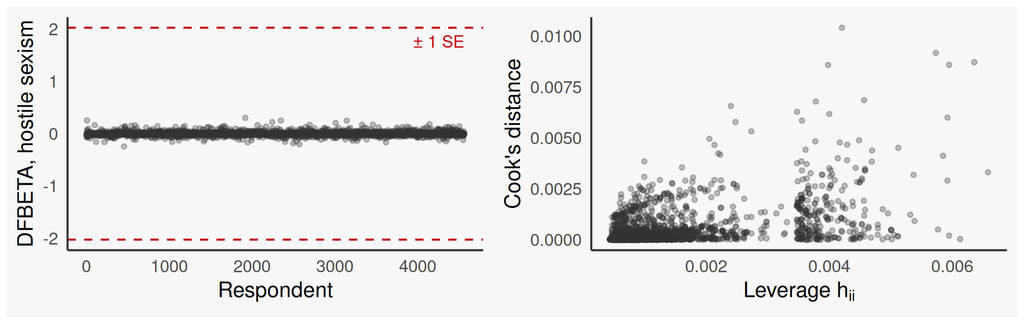

- No single respondent moves $\hat{\beta}_{HS}$ by more than 0.30, against a robust SE of 2.03. The largest Cook’s distance is 0.010
- With $n$ in the thousands and **bounded** regressors, no one point can matter much. Influence is more of a **small-sample** and **heavy-tailed** $X$ problem.

## Leverage and robust SEs: HC1, HC2, HC3

- The HC0 “filling” plugs in $\hat{e}_i^2$ for $\sigma_i^2$, but residuals at high-leverage points are **too small**
  - So HC0 standard errors tend to be too small in small samples
- The usual corrections (MacKinnon and White 1985)

  $$\text{HC1}: \frac{n}{n-k}\hat{e}_i^2 \qquad \text{HC2}: \frac{\hat{e}_i^2}{1 - h_{ii}} \qquad \text{HC3}: \frac{\hat{e}_i^2}{(1 - h_{ii})^2}$$
  - HC2 undoes the $(1 - h_{ii})$ shrinkage. It’s **unbiased** under homoskedasticity
  - HC3 plugs in the squared **leave-one-out** errors - most conservative.
- In large samples without massively high-leverage points, they’re all basically the same

```r
round(sapply(c("HC0", "HC1", "HC2", "HC3"), \(t) sqrt(diag(vcovHC(fit_full, type = t)))[2:3]), 4)
```

```
                     HC0    HC1    HC2    HC3
hostile_sexism    2.0256 2.0267 2.0277 2.0298
racial_resentment 1.5729 1.5737 1.5743 1.5758
```

## Regression as a linear smoother

- $\hat{\mathbf{Y}} = \mathbf{P}\mathbf{Y}$: every fitted value is a **weighted sum** of the outcomes.

  $$\hat{Y}(\mathbf{x}) = \sum_{j=1}^n w_j(\mathbf{x})\, Y_j \qquad w_j(\mathbf{x}) = \mathbf{x}^\prime(\mathbf{X}^\prime\mathbf{X})^{-1}\mathbf{X}_j$$
- Our earlier **Nadaraya-Watson** estimator had the same form, with **kernel** weights

  $$\hat{Y}(x) = \sum_{j=1}^n w_j(x)\, Y_j \qquad w_j(x) = \frac{K_h(X_j - x)}{\sum_{l} K_h(X_l - x)}$$
- Both are **linear smoothers**: $\hat{\mathbf{Y}} = \mathbf{S}\mathbf{Y}$ for some $n \times n$ matrix $\mathbf{S}$ built from $\mathbf{X}$
  - In both cases, the weights sum to 1
  - $\text{tr}(\mathbf{S})$ measures how flexible the fit is: the **effective number of parameters** ($k$ for OLS)

## The weights behind a fitted value

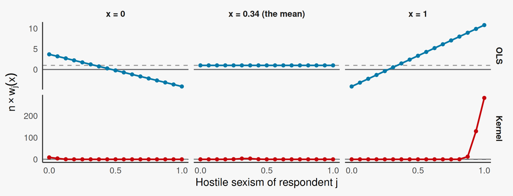

## Comparing to kernel regression

- **Kernel** weights are **local**: only respondents near $x$ count
  - Few respondents near $x = 1$, so each gets a lot of weight: the fit there is **noisy**
- **OLS** weights are **global** and **linear** in $X_j$
  - At $\bar{X}$, everyone counts equally: the fitted value is just $\bar{Y}$
  - Away from $\bar{X}$, the respondents **farthest** from the mean on the **same** side count most…
  - … and those on the **other** side get **negative** weight
- **Bias-variance** trade-off:
  - OLS borrows strength from the whole sample (low variance), but its prediction at $x$ relies on observations nowhere near $x$

## The coefficient as a weighted sum of outcomes

- The **coefficients** are linear in $\mathbf{Y}$ too. By FWL, for the coefficient on $X_{i1}$

  $$\hat{\beta}_1 = \frac{\sum_i \tilde{X}_{i1} Y_i}{\sum_i \tilde{X}_{i1}^2} = \sum_{i=1}^n \omega_i Y_i \qquad \omega_i = \frac{\tilde{X}_{i1}}{\sum_j \tilde{X}_{j1}^2}$$
  - $\tilde{X}_{i1}$: the residual from regressing $X_{i1}$ on the other covariates
  - The weights sum to **zero** and $\sum_i \omega_i X_{i1} = 1$: a “contrast” of outcomes
- Respondents whose $X_{i1}$ is **well predicted** by the controls ($\tilde{X}_{i1} \approx 0$) contribute **nothing**

## Next week

- **Second Midterm Exam** tomorrow, Wednesday, November 18
- Missing data
  - What happens when some observations are **missing** from our data
  - Bounds on the true sample mean
  - **Weighting** estimators under various assumptions on the missingness process
- Survey weighting
  - **Stratified** and **clustered** sampling from a target population
  - **Post-stratification** to adjust for non-representative samples.

## References

Cook, R. Dennis. 1977. “Detection of Influential Observation in Linear Regression.” *Technometrics* 19 (1): 15–18. https://doi.org/10.1080/00401706.1977.10489493.

MacKinnon, James G., and Halbert White. 1985. “Some Heteroskedasticity-Consistent Covariance Matrix Estimators with Improved Finite Sample Properties.” *Journal of Econometrics* 29 (3): 305–25. https://doi.org/10.1016/0304-4076(85)90158-7.